# Projet_modélisation_épidémiologie

Chloe Perou - Raphaelle Lebailly

2023-10-26

# Projet MEPI : Analyse de sensibilité d’un modèle épidémiologique

Effacer les variables et les graphiques créés lors d’exécutions précédentes

```r
rm(list=ls())
graphics.off()
```

Charger les librairies nécessaires

```r
library(ggplot2)
library(tidyr)
library(sensitivity)
```

## 1. Description du modèle

### a. Définir le type de modèle

Le modèle est déterministe (sans facteur aléatoire) à compartiments (états de santé et classe d’âge) à temps discret (par jour) sur une période de 2 ans..

On considère dans ce modèle :

**3 classes d’âge :**  
- *NN* : Nouveaux-nés  
- *J* : Jeunes  
- *A* : Adultes  
- *N* : Population totale

**4 états de santé :**  
- *S* : Sain  
- *IN* : Latent  
- *II* : Infectieux  
- *R* : Remis

### b. Les processus biologiques en jeu sont :

- La mort naturelle
- La mort liée à la maladie
- La naissance de nouveaux-nés
- La croissance (changement de classe d’âge) linéaire unidirectionnelle (sans regression)
- Transmission de la maladie
- Période de latence entre état infecté neutre et infecté infectieux (incubation)
- Période d’immunité

### c. Les équations associées :

**Classe d’âge NN (nouveaux nés)**

$$S_{NN_{t+1}} = S_{NN_t} (1 - m_{1} -
t_{1} - \frac{trans . I_{N_t}}{N}) + loss . R_{NN_t} + max( 0,\ s_{R} .
portee . \sum_{J} . f_{2}) + \sum_{A} . f_{3} (1 - \frac{N}{K})$$

$$L_{NN_{t+1}} = L_{NN_t}(1 - m_{1} - t{1}
- \text{lat}) + \frac{\text{trans} . S_{NN_t} . I_{N_t}}{N}$$

$$I_{NN{t+1}} = I_{NN_t}(1 - m_{1} - madd
- t_{1} - rec) + lat . L_{NN_t}$$

$$R_{NN{t+1}} = R_{NN_t}(1 - m_{1} - t_{1}
- loss) + rec . I_{NN_t}$$

**Classe d’âge J (jeunes)**

$$S_{J_{t+1}} = S_{NN_t}.t_{1} + S_{J_t}(1
- m_{2} - t_{2} - \frac{trans . I_{N_t}}{N}) + loss.R_{J_t}$$

$$L_{J_{t+1}} = L_{NN_t}.t_{1} +
IN_{J_t}(1 - m_{2} - t_{2} - lat) +
\frac{trans.S_{J_t}.I_{N_t}}{N}$$

$$I_{J_{t+1}} = I_{NN_t}.t_{1} + I_{J_t}(1
- m_{2} - madd - t_{2} - rec) + lat.L_{J_t}$$

$$R_{J_{t+1}} = R_{NN_t}.t_{1} + R{J_t}(1
- m_{2} - t_{2} - loss) + rec.I_{J_t}$$

**Classe d’âge A (adultes)**

$$S_{A_{t+1}} = S_{J_t}.t_{2} + S_{A_t}(1
- m_{3} - \frac{trans.I_{N_t}}{N}) + loss.R_{A_t}$$

$$L_{A_{t+1}} = L_{J_t}.t_{2} + L_{A_t}(1
- m_{3} - lat) + \frac{trans.S_{A_t}.I_{N_t}}{N}$$

$$I_{A_{t+1}}= I_{J_t}.t_{2} + I{A_t}(1 -
m_{3} - madd - rec) + lat.L_{A_t}$$

$$R_{A_{t+1}}=R_{J_t}.t_{2}+R_{A_t}(1-m_{3}-loss)+rec.I_{A_t}$$

**Total**
$$S_{N_{t+1}}=S_{NN_{t+1}}+S_{J_{t+1}}+S_{A_{t+1}}$$

$$L_{N_{t+1}}=L_{NN_{t+1}}+L_{J_{t+1}}+L_{A_{t+1}}$$

$$I_{N_{t+1}}=I_{NN_{t+1}}+I_{J_{t+1}}+I_{A_{t+1}}$$

$$R_{N_{t+1}}=R_{NN_{t+1}}+R_{J_{t+1}}+R_{A_{t+1}}$$

**Niveau d’infectiosité de l’agent pathogène par jour**

$$Nv_{inf_{t+1}}=trans.S_{N_t}(\frac{I_{N_t}}{N})$$

### d. Schéma des transitions entre états

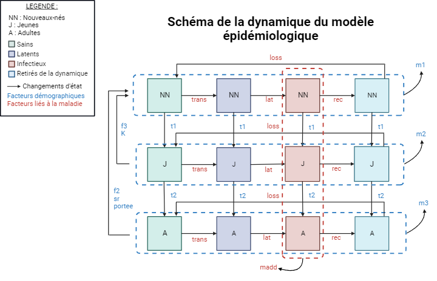

```r
knitr::include_graphics("Schema_MEPI.png")
```

### e. Les hypothèses principales du modèle sont :

Paramètres liés à l’AP :

- L’AP peut infecter les individus sains de toutes les classes d’âge
- Une période de latence précède l’état infectieux de l’individu infecté
- Après la période d’immunité, l’individu redevient sensible à l’AP

### f. Les conditions initiales :

- 27 Nouveaux-nés sains
- 23 Jeunes sains
- 36 Adultes sains
- 1 Adulte infectieux

### g. Les sorties possibles du modèle sont :

$$\text{Taux d'infectés (latents et
infectieux) le dernier jour} = \frac{L_{N_t} +
{I_{N_t}}}{N_t}$$
$$\text{Incidence de l'AP le dernier
jour} = \frac{transS_{N_t}I_{N_t}}{N_t}$$
$$\text{Nombre maximum d'infectieux en 2
ans} = max(I_{N_t})$$
$$\text{Incidence de l'AP sur 1 an} =
\sum_{t=1}^{365}\frac{transS_{N_t}I_{N_t}}{N_t}$$

### h. Lister les paramètres du modèle

Paramètres liés à la population étudiée :

- *K* : **100**, Nombre maximal d’individus que le milieu peut supporter
- *sr* : **0.5**, Sex-ratio
- *m1* : **0.0014**, Mortalité naturelle des nouveaux-nés
- *m2* : **0.00029**, Mortalité naturelle des jeunes
- *m3* : **0.0019**, Mortalité naturelle des adultes
- *f2* : **0.0019**, Taux de fécondité des jeunes
- *f3* : **0.0082**, Taux de fécondité des adultes
- *portee* : **5**, Effectif maximal d’une portée
- *t1* : **1/365**, Probabilité de passage de la classe d’âge “nouveau-né” à “jeune”
- *t2* : **1/365**, Probabilité de passage de la classe d’âge “jeune” à “adulte”

Paramètres liés à la maladie :

- *trans* : **0.3**, force d’infection
- *lat* : **1/5**, taux de la latence
- *rec* : **1/20**, taux de passage à un état d’immmunité
- *loss* : **1/100**, taux de passage d’un état d’immunité à un état sensible (sain)
- *madd* : **0.001**, mortalité lié à l’infection par l’AP

### i. Réaliser des graphiques afin d’illustrer le comportement du modèle avec les valeurs nominales

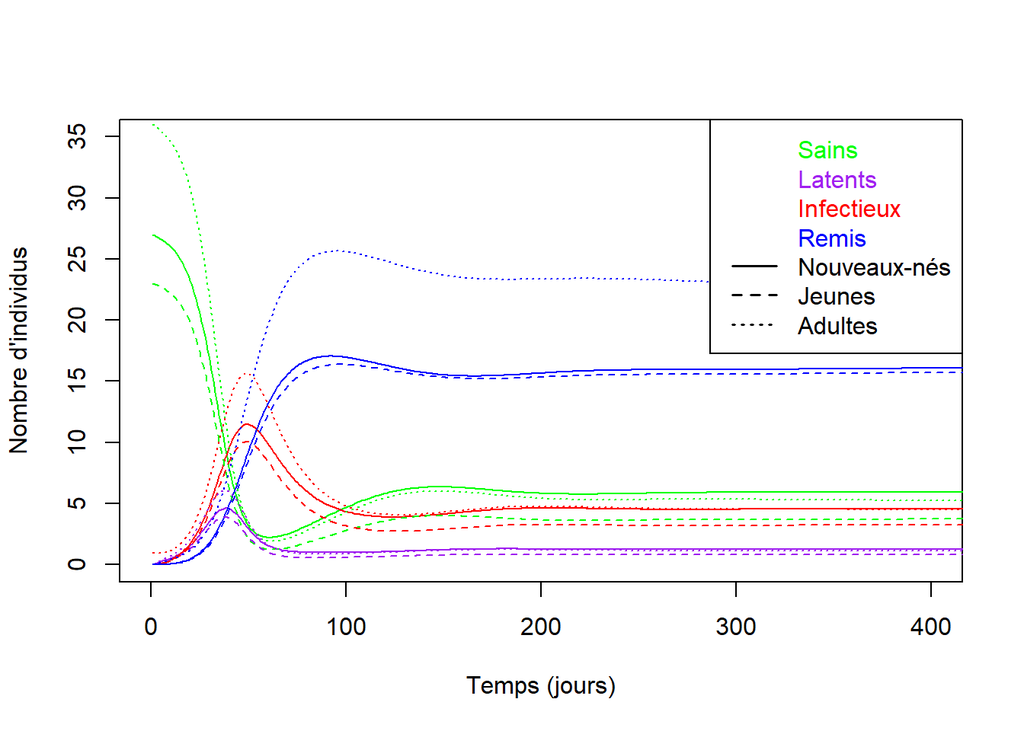

```
##       Taux_inf Last_incidence Nbr_infectes Year_incidence
## [1,] 0.1825966      0.6450925     37.20512       280.9444
```

Suite à l’introdutcion d’un individu infecté par l’agent pathogène avec les paramètres aux valeurs nominales, une vague de propagation se déclanche. Elle est rapidement stabilisée car de nombreux individus sont immunisés. Après 2 ans les proportions d’individus dans chaque classes sont stabilisés, les sorties calculées le dernier jour sont donc les sorties stables.  
- Le taux d’infectés le dernier jour de la modélisation vaut 0,18.  
- L’incidence le dernier jour de la modélisation vaut 0,65.  
- Le nombre maximum d’infectés en une journée est de 37,2 individus.  
- La somme de l’incidence sur une année vaut 280,9.

## 2. Analyse de sensibilité : méthode OAT

### a. Justifier les valeurs testées

On fait varier les valeurs à +/- 25% des valeurs nominales. Cela permet de réaliser une analyse de sensibilité en gardant des valeurs biologiquement viables.

### b. Script de l’analyse OAT

Fonction du modèle à analyser

```r
modAppli <- function(parametre){

  # CONDITIONS DE SIMULATION
  temps = 2*365; # nb de pas de temps (en jours)
  # initialisation pour la sauvegarde de 4 sorties ponctuelles pour chaque jeu de parametres
  sorties <- matrix(0, nrow=nrow(parametre), ncol=4)

  # boucle des scenarios de l'?chantillonnage de l'AS
  for (i in 1:nrow(parametre)) {

    # STRUCTURE & PARAMETRES DU MODELE

    # Parametres demographiques
    K = parametre[i,1];         # Nombre maximal d'individus que le milieu peut supporter
    sr = parametre[i,2];        # Sex-ratio
    m1 = parametre[i,3];        # Mortalité naturelle des nouveaux-nés
    m2 = parametre[i,4];        # Mortalité naturelle des jeunes
    m3 = parametre[i,5];        # Mortalité naturelle des adultes
    f2 = parametre[i,6];        # Taux de fécondité des jeunes
    f3 = parametre[i,7];        # Taux de fécondité des adultes
    portee = parametre[i,8];    # Effectif maximal d'une portée
    t1 = parametre[i,9];        # Probabilité de passage de la classe d'âge "nouveau-né" à "jeune"
    t2 = parametre[i,10];       # Probabilité de passage de la classe d'âge "jeune" à "adulte"

    # Parametres lies a l'agent pathogène
    trans = parametre[i,11];  # Force d'infection
    lat = parametre[i,12];    # Taux de la latence
    rec = parametre[i,13];    # Taux de passage à un état d'immmunité
    loss = parametre[i,14];   # Taux de passage d'un état d'immunité à un état sensible (sain)
    madd = parametre[i,15];   # Mortalité lié à l'infection par l'AP

    # INITIALISATION
    MAT <- array(0, dim=c(4,4,temps)); # nb indiv par classe d'age en ligne (derniere ligne = pop tot), etat de sante en colonne, pas de temps (dimension 3)
    nvinf <- array(0, dim=c(temps));
    # conditions initiales (la population est a sa structure d'equilibre, calculee par ailleurs)
    MAT[1,1,1] <- 27; # Effectif des individus nouveaux-nes sains le premier jour
    MAT[2,1,1] <- 23; # Effectif des individus jeunes sains le premier jour
    MAT[3,1,1] <- 36; # Effectif des individus adultes sains le premier jour
    MAT[3,3,1] <- 1;  # Effectif des individus adultes infectes infectieux le premier jour

    # Effectifs par etat de sante
    MAT[4,1,1] <- sum(MAT[1:3,1,1]); MAT[4,2,1] <- sum(MAT[1:3,2,1]); MAT[4,3,1] <- sum(MAT[1:3,3,1]); MAT[4,4,1] <- sum(MAT[1:3,4,1]);

    # SIMULATIONS
    # Boucle du temps
    for (t in 1:(temps-1)) {
     # Classe d'age Nouveau-né
      # RQ : les naissances sont XX, les nouveaux nes etant dans l'etat NN
      N <- sum(MAT[4,,t]);  # Taille de la pop en t
      MAT[1,1,t+1] <- MAT[1,1,t]*(1-m1-t1-trans*MAT[4,3,t]/N) + loss*MAT[1,4,t]      + max(0, sr*portee*(sum(MAT[2,,t])*f2 + sum(MAT[3,,t])*f3) * (1 - N/K));
      MAT[1,2,t+1] <- MAT[1,2,t]*(1-m1-t1-lat)            + trans*MAT[1,1,t]*MAT[4,3,t]/N;
      MAT[1,3,t+1] <- MAT[1,3,t]*(1-m1-madd-t1-rec)           + lat*MAT[1,2,t];
      MAT[1,4,t+1] <- MAT[1,4,t]*(1-m1-t1-loss)           + rec*MAT[1,3,t];
     # classe d'age Jeune
      MAT[2,1,t+1] <- MAT[1,1,t]*t1 + MAT[2,1,t]*(1-m2-t2-trans*MAT[4,3,t]/N) + loss*MAT[2,4,t];
      MAT[2,2,t+1] <- MAT[1,2,t]*t1 + MAT[2,2,t]*(1-m2-t2-lat)          + trans*MAT[2,1,t]*MAT[4,3,t]/N;
      MAT[2,3,t+1] <- MAT[1,3,t]*t1 + MAT[2,3,t]*(1-m2-madd-t2-rec)     + lat*MAT[2,2,t];
      MAT[2,4,t+1] <- MAT[1,4,t]*t1 + MAT[2,4,t]*(1-m2-t2-loss)         + rec*MAT[2,3,t];
     # classe d'age Adulte
      MAT[3,1,t+1] <- MAT[2,1,t]*t2 + MAT[3,1,t]*(1-m3-trans*MAT[4,3,t]/N)  + loss*MAT[3,4,t];
      MAT[3,2,t+1] <- MAT[2,2,t]*t2 + MAT[3,2,t]*(1-m3-lat)             + trans*MAT[3,1,t]*MAT[4,3,t]/N;
      MAT[3,3,t+1] <- MAT[2,3,t]*t2 + MAT[3,3,t]*(1-m3-madd-rec)            + lat*MAT[3,2,t];
      MAT[3,4,t+1] <- MAT[2,4,t]*t2 + MAT[3,4,t]*(1-m3-loss)            + rec*MAT[3,3,t];
     # calcul des effectifs par etat de sante
      MAT[4,1,t+1] <- sum(MAT[1:3,1,t+1]); MAT[4,2,t+1] <- sum(MAT[1:3,2,t+1]); MAT[4,3,t+1] <- sum(MAT[1:3,3,t+1]); MAT[4,4,t+1] <- sum(MAT[1:3,4,t+1]);
      nvinf[t+1]   <- trans*MAT[4,1,t]*MAT[4,3,t]/N

    }# fin boucle temps

    # Sorties ponctuelles a analyser

    # Taux d'infectés le dernier jours
    sortie1 <- (MAT[4,2,temps] + MAT[4,3,temps]) / sum(MAT[4,,temps])
    # Incidence le dernier jour
    sortie2 <- nvinf[temps]
    # Nombre maximum d'infectieux en 2 ans
    sortie3 <- max(MAT[4,3,1:temps])
    # Incidence sur l'année
    sortie4 <- sum(nvinf[1:365])

    sorties[i,1] <- sortie1;
    sorties[i,2] <- sortie2;
    sorties[i,3] <- sortie3;
    sorties[i,4] <- sortie4;

  }# fin boucle scenarios AS
  return(sorties)
}
```

Stocker les valeurs des paramètres.

```r
ValNominale = c(100, 0.5, 0.0014, 0.00029, 0.0019, 0.0019, 0.0082, 5, 1/365, 1/365, 0.3, 1/5, 1/20, 1/100, 0.001)
ParamNames = c("K", "sr", "m1", "m2", "m3", "f2", "f3", "portee", "t1", "t2", "trans", "lat", "rec", "loss", "madd")

# Gammes de variation des paramètres
ParamRanges = data.frame(
  lower = ValNominale * 0.75,
  upper = ValNominale * 1.25
  )

# Matrice des paramètres de base
param_matrix_first <- matrix(ValNominale,
                             nrow = 1,
                             ncol = length(ValNominale))

# Matrice des paramètres variants
param_matrix_var <- matrix(0,
                           nrow = 10,
                           ncol = length(ValNominale))
for (i in 1:length(ValNominale)) {
  param_matrix_var[, i] <- seq(ParamRanges$lower[i], ParamRanges$upper[i], length.out = 10)
  }

# Créer un dataframe qui stock les résultats de la sortie 1 de l'analyse de sensibilité
SensitivityResults <- data.frame(Parameter = character(0), Sensitivity = numeric(0))
```

Réaliser l’analyse OAT.

```r
for (i in 1:length(ValNominale)) {
  for (j in 1:10) {
    # Faire varier notre paramètre
    param_matrix <- param_matrix_first
    param_matrix[1,i] <- param_matrix_var[j,i]

    # Exécuter le modèle pour chaque combinaison de paramètres
    output <- modAppli(param_matrix)

    # Créez un data.frame temporaire pour stocker les résultats de cette itération
    temp_df <- data.frame(Parameter = ParamNames[i],
                          Val = param_matrix[, i],
                          Sensitivity1 = output[,1],
                          Sensitivity2 = output[,2],
                          Sensitivity3 = output[,3],
                          Sensitivity4 = output[,4])

    # Ajoutez les résultats à SensitivityResults
    SensitivityResults <- rbind(SensitivityResults, temp_df)
  }
}
```

### c. Réaliser des figures illustrant le comportement du modèle

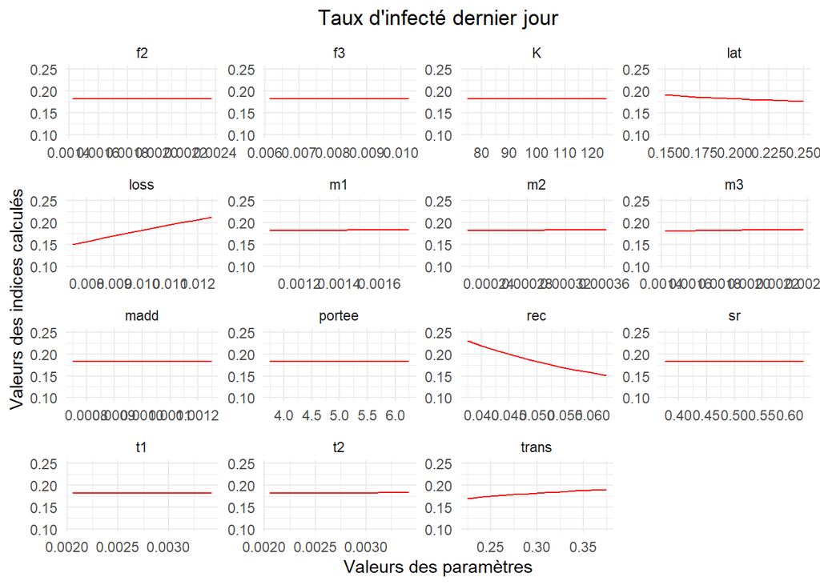

```r
ggplot(SensitivityResults, aes(x = Val, y = Sensitivity1)) +
  geom_line(aes(color = "Sensitivity1")) +
  labs(x = "Valeurs des paramètres",
       y = "Valeurs des indices calculés",
       colour = NULL) +
  ggtitle ("Taux d'infecté dernier jour") +
  theme_minimal() +
  facet_wrap(~Parameter, scales = "free") +
  theme(plot.title = element_text(hjust = 0.5)) +
  scale_color_manual(values = c("Sensitivity1" = "red"),
                     labels = c("Taux d'infecté dernier jour")) +
  coord_cartesian(ylim = c(0.1, 0.25)) +
  guides(color = FALSE)
```

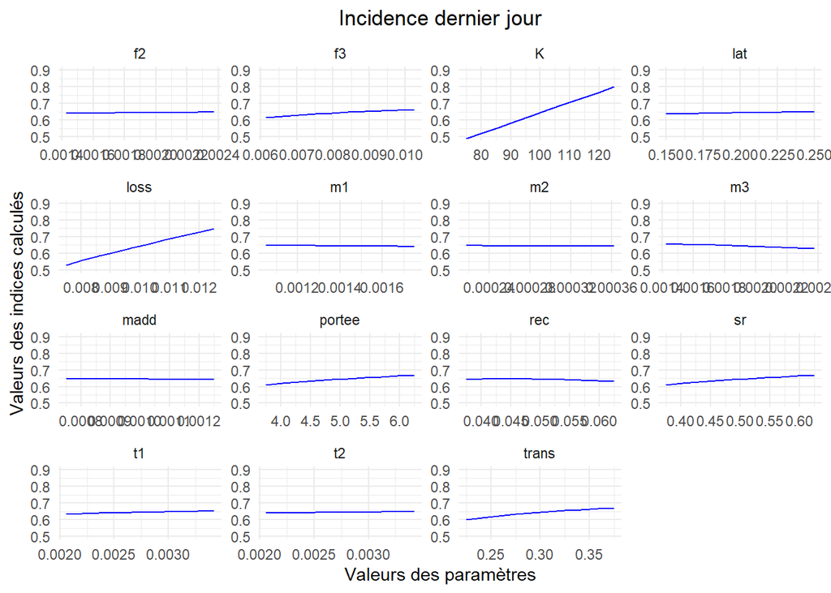

```r
ggplot(SensitivityResults, aes(x = Val, y = Sensitivity2)) +
  geom_line(aes(color = "Sensitivity2")) +
  labs(x = "Valeurs des paramètres",
       y = "Valeurs des indices calculés",
       colour = NULL) +
  ggtitle ("Incidence dernier jour") +
  theme_minimal() +
  facet_wrap(~Parameter, scales = "free") +
  theme(plot.title = element_text(hjust = 0.5)) +
  scale_color_manual(values = c("Sensitivity2" = "blue"),
                     labels = c("Incidence dernier jour")) +
  coord_cartesian(ylim = c(0.5, 0.9)) +
  guides(color = FALSE)
```

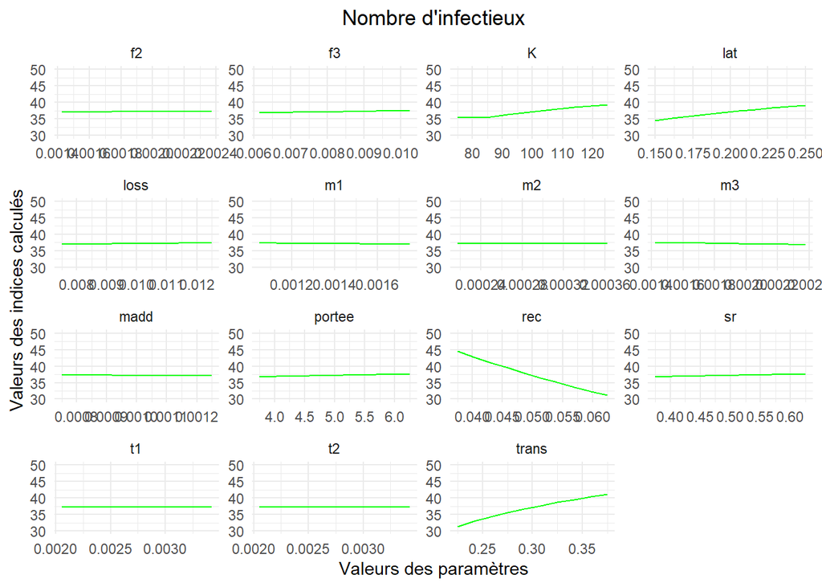

```r
ggplot(SensitivityResults, aes(x = Val, y = Sensitivity3)) +
  geom_line(aes(color = "Sensitivity3")) +
  labs(x = "Valeurs des paramètres",
       y = "Valeurs des indices calculés",
       colour = NULL) +
  ggtitle ("Nombre d'infectieux") +
  theme_minimal() +
  facet_wrap(~Parameter, scales = "free") +
  theme(plot.title = element_text(hjust = 0.5)) +
  scale_color_manual(values = c("Sensitivity3" = "green"),
                     labels = c("Nombre d'infectieux")) +
  coord_cartesian(ylim = c(30, 50)) +
  guides(color = FALSE)
```

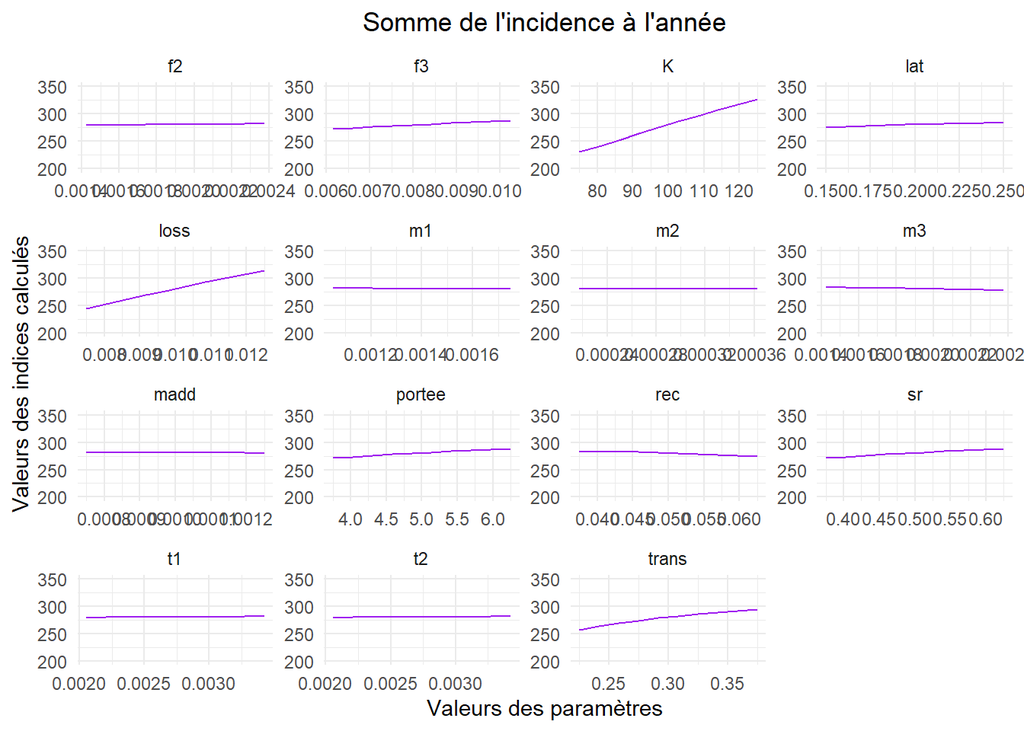

```r
ggplot(SensitivityResults, aes(x = Val, y = Sensitivity4)) +
  geom_line(aes(color = "Sensitivity4")) +
  labs(x = "Valeurs des paramètres",
       y = "Valeurs des indices calculés",
       colour = NULL) +
  ggtitle ("Somme de l'incidence à l'année") +
  theme_minimal() +
  facet_wrap(~Parameter, scales = "free") +
  theme(plot.title = element_text(hjust = 0.5)) +
  scale_color_manual(values = c("Sensitivity4" = "purple"),
                     labels = c("Somme de l'incidence à l'année")) +
  coord_cartesian(ylim = c(200,350)) +
  guides(color = FALSE)
```

### d. Interpréter les résultats et expliciter des limites possibles

### d. Interpréter les résultats et expliciter des limites possibles

- L’analyse OAT suppose que les paramètres sont indépendants, elle ne tient pas compte d’une potentielle interaction.
- Les valeurs testées sont déterminées suite à des hypothèses donc subjectives.
- Ces valeurs ne contienent pas toutes les valeurs biologiques possibles ce qui peut consuire à une sous-estimation de l’impact des paramètres.

## 3. Analyse de sensibilité : Méthode Morris

Visualiser les résultats

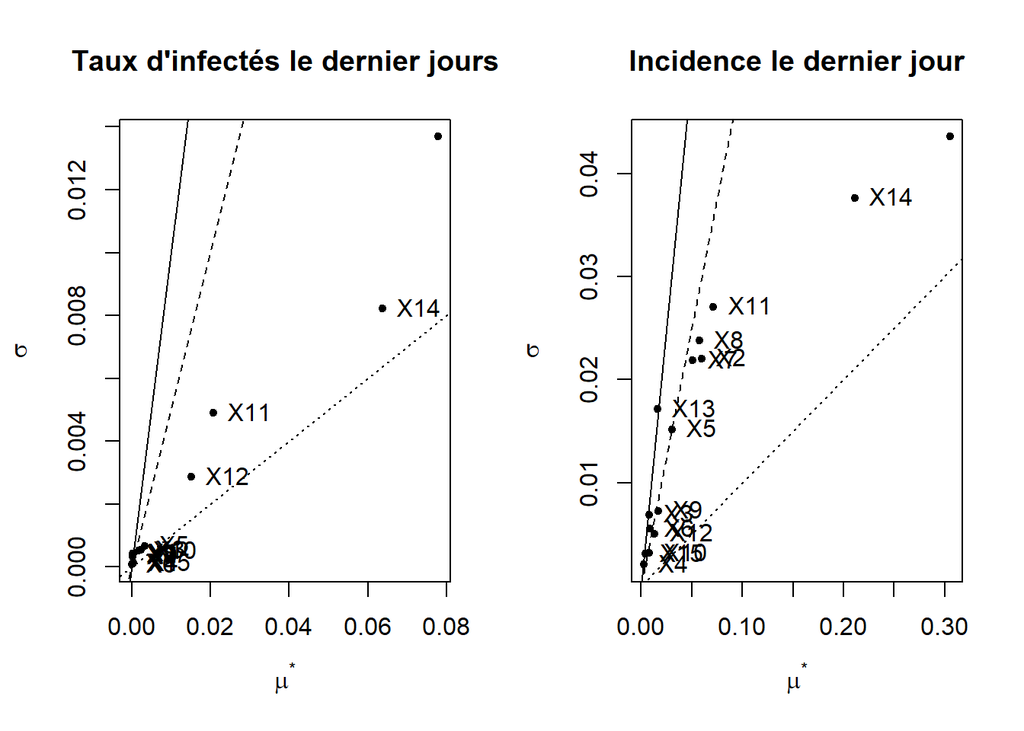

```r
par(mfrow = c(1, 2))
plot(morris_results, y_col = 1, main = "Taux d'infectés le dernier jours", atpen = T)
abline(a = 0, b = 1)
abline(a = 0, b = 0.5, lty = 2)
abline(a = 0, b = 0.1, lty = 3)
plot(morris_results, y_col = 2, main = "Incidence le dernier jour")
abline(a = 0, b = 1)
abline(a = 0, b = 0.5, lty = 2)
abline(a = 0, b = 0.1, lty = 3)
```

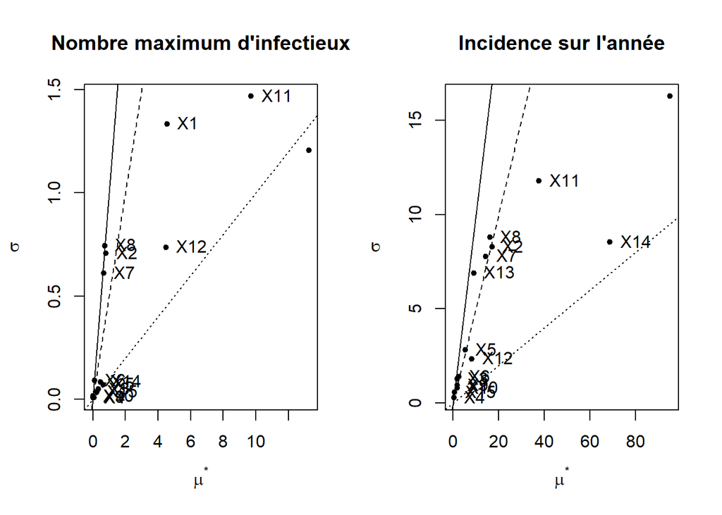

```r
plot(morris_results, y_col = 3, main = "Nombre maximum d'infectieux")
abline(a = 0, b = 1)
abline(a = 0, b = 0.5, lty = 2)
abline(a = 0, b = 0.1, lty = 3)
plot(morris_results, y_col = 4, main = "Incidence sur l'année")
abline(a = 0, b = 1)
abline(a = 0, b = 0.5, lty = 2)
abline(a = 0, b = 0.1, lty = 3)
```

Sigma mesure les interactions et les relations non linéaires entre les paramètres.  
Mu* mesure la sensibilité du paramètre.

Les bornes ont été réalisées en s’appuyant sur l’article de (Menberg, 2016).  
Menberg, Kathrin & Heo, Y & Choudhary, R. (2016). Sensitivity analysis methods for building energy models: Comparing computational costs and extractable information. Energy and Buildings. 133. 433-445. 10.17863/CAM.6789.  
Ces bornes permettent de délimiter les paramètres dans des classes différentes.  
L’espace le plus à gauche signifie que le paramètre est non linéaire et/ou non monotone.  
Vers la droite, la zone détermine les paramètres toujours monotone.  
Ensuite, les paramètres qui sont monotones.  
La zone la plus à droite a les paramètres linéaires.

## 4. Analyse de sensibilité : Méthode FAST

Lien pour la méthode sur R : https://rdrr.io/cran/fast/man/sensitivity.html

### a. Le package utilisé pour l’analyse de sensibilité avec la méthode FAST est ‘sensitivity’.

Ce package permet d’utiliser des méthodes d’analyse de sensibilité globales et non de screening comme précédemment avec les méthodes OAT et Morris. C’est-à-dire que l’on peut prendre en compte le caractère continu des variables d’entrée et les intéractions entre elles. On peut donc étudier les effets **principaux** (paramètre seul) et **totaux** (intéractions possibles avec d’autres paramètres + paramètre seul) des variables d’entrée. Ce sont des méthodes basées sur la décomposition de la variance. Dans cette catégorie, nous pouvons retrouver la méthode **FAST**, ou ‘Fourier Amplitude Sensitivity Test’, mais encore la méthode du plan factoriel ou Sobol.

Le principe est de choisir pour cette étude : - Les variables d’entrée que l’on souhaite suivre. *Dans notre cas, nous choisissons tous les paramètres d’entrée.* - Leur plage de variation, avec une valeur minimale et une valeur maximale qui bornent cette plage. *Nous choisissons une variation de +/- 25% de la valeur de base du paramètre afin de rester dans des valeurs réalistes pour le modèle.* - Une loi de distribution qui régit la plage de variation. *Nous avons choisi une loi uniforme (‘qunif’) afin d’avoir une variation homogène de nos paramètres et de n’avoir aucun a priori sur ces derniers.*

Un certain nombre de simulations est effectué pour chaque paramètre dans le but de faire une décomposition de la variance. Le nombre de simulation est important à déterminer car top peu de simulations ne permettent pas de rendre compte finement des variations de la variance pour les paramètres, et trop de simulations peuvent être très coûteuses en temps de calcul. *Dans notre cas, nous allons simuler pour 100 et 1000 scénarios*.

En sortie de l’analyse, des **indices de sensibilité** sont donnés pour chaque variable d’entrée étudiée et des graphiques nous permettent de nous représenter les effets des différents paramètres.

**Design expérimental**

### b. Pour 100 simulations

On définit le design expérimental en premier lieu, puis on l’appelle avec notre fonction afin de faire l’analyse de sensibilité. Pour ce faire, on utilise la fonction ‘fast99’.

```r
ParamRanges<-apply( X = cbind(inf = ValNominale*0.75, sup = ValNominale*1.25), 1, function(x){list(min=x[1], max = x[2])}) # plage de variation des paramètres en tant que liste de listes

des_xp100<-fast99(model = NULL,
                  factors = ParamNames,
                  n = 100,
                  q = rep("qunif",15),
                  q.arg = ParamRanges) # Pour creer le design expérimental
des_xp1<-des_xp100$X # On conserve le tableau avec les variations par paramètres
length(des_xp1[,1]) # Longueur du tableau
```

```
## [1] 1500
```

On obtient donc un tableau à 1500 lignes, pour la simulation du paramètre seul, et des intéractions avec les 14 autres pour 100 scénarios.

### c. Variation des paramètres

Maintenant qu’on a le design experimental, on peut regarder comment les variations des paramètres remplissent l’espace. Ici, on représente les variations des paramètres 2 à 2 ici on ne représente que les paramètres K et sr.

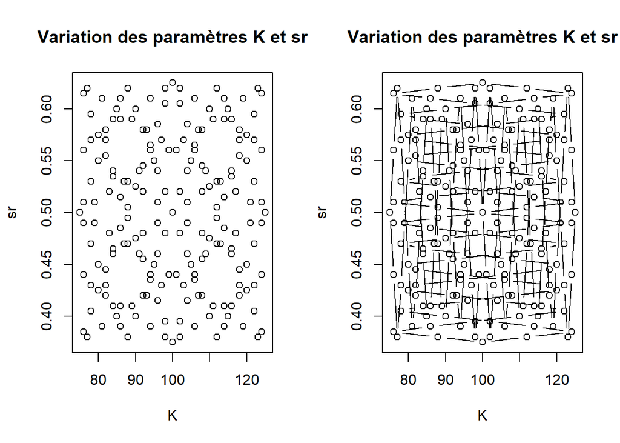

L’espace des paramètres est rempli de la même manière quelque soient les paramètres deux à deux.

*A priori*, on peut voir que l’espace est assez bien rempli.

### d. Pour 1000 trajectoires

On effectue les mêmes démarches pour 1000 scénarios.

```r
des_xp1000<-fast99(model = NULL,
                   factors = ParamNames,
                   n = 1000,
                   q = rep("qunif",15),
                   q.arg = ParamRanges) # Pour creer le design expérimental
des_xp2<-des_xp1000$X # On conserve le tableau avec les variations par paramètres
length(des_xp2[,1]) # Longueur du tableau
```

```
## [1] 15000
```

On obtient donc un tableau de 15000 lignes.

Et pour le design expérimental :

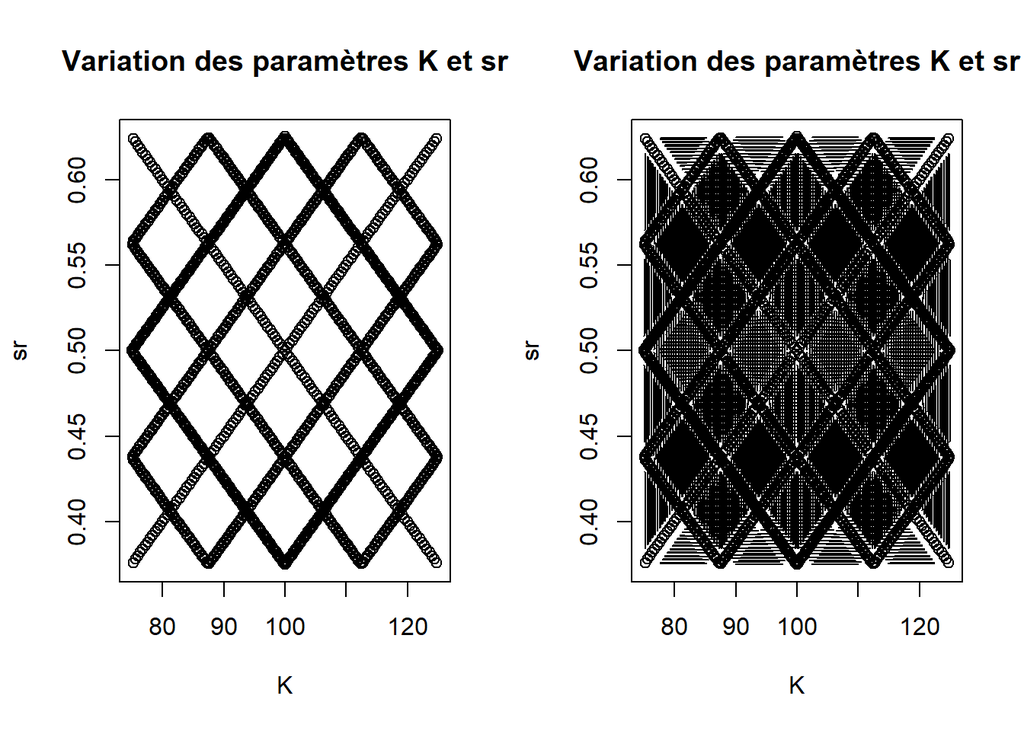

On obtient donc un recouvrement plus important de l’espace que pour seulement 100 simulations.

### e. Comparaison des deux designs expérimentaux

*A priori*, on a l’impression que pour 100 scénarios, on a un recouvrement plus homogène de l’espace qui suggèrerait potentiellement une analyse FAST plus précise et plus fiable. En revanche, si l’on compare les deux recouvrements, on se rend compte que pour 100 simulations, il y a plus de trous à certains endroits, ce qui rend donc ce paramétrage moins efficace que pour 1000 scénarios.

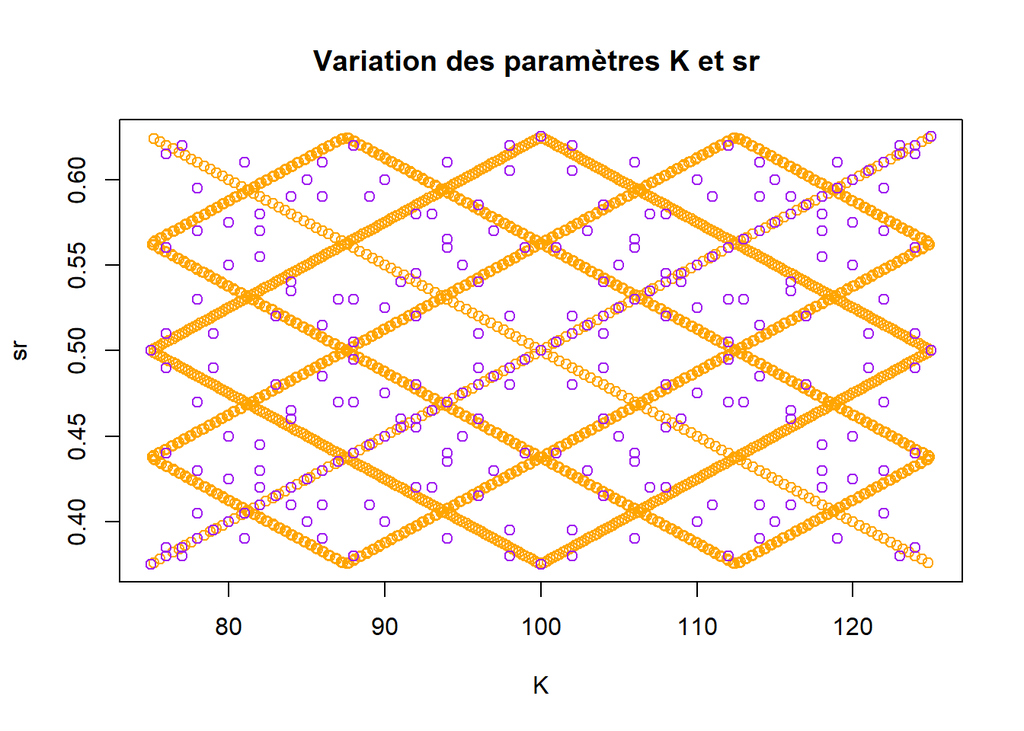

### f. Lancement de l’analyse avec le modèle

Après avoir créé les deux designs expérimentaux, on peut donc passer à l’analyse FAST.

```r
FAST1<-fast99(model = modAppli,
              factors = ParamNames,
              n = 100,
              q = rep("qunif",15),
              q.arg = ParamRanges)
FAST2<-fast99(model = modAppli,
              factors = ParamNames,
              n = 1000,
              q = rep("qunif",15),
              q.arg = ParamRanges)
```

### g. Distribution des sorties obtenues

#### Pour 100 simulations

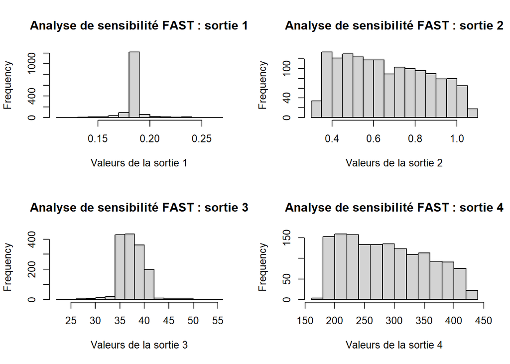

On obtient donc un histogramme pour chaque sortie du modèle avec la fréquence donnée pour chaque plage de valeur de sortie obtenue.

Par exemple, sur les 1500 simulations, pour la première sortie, on retrouve environ 1200 fois une valeur comprise entre 0.18 et 0.19, soit dans 80% des cas. Cela signifie que faire varier les paramètres d’entrée influence peu la variation de la sortie 1. Ce comportement est aussi observé pour la sortie 3, de manière moins importante que pour la sortie 1.

En revanche, on retrouve une fréquence à peu près similaire sur l’ensemble des valeurs que peuvent prendre la sortie 2 et la sortie 4. C’est-à-dire que faire varier une valeur d’un paramètre d’entrée fait beaucoup varier la valeur de sortie.

Les sorties 2 et 4 sont donc sensibles au choix du paramétrage du modèle -dans le cas de 100 simulations- , contrairement aux sorties 1 et 3.

#### Pour 1000 simulations

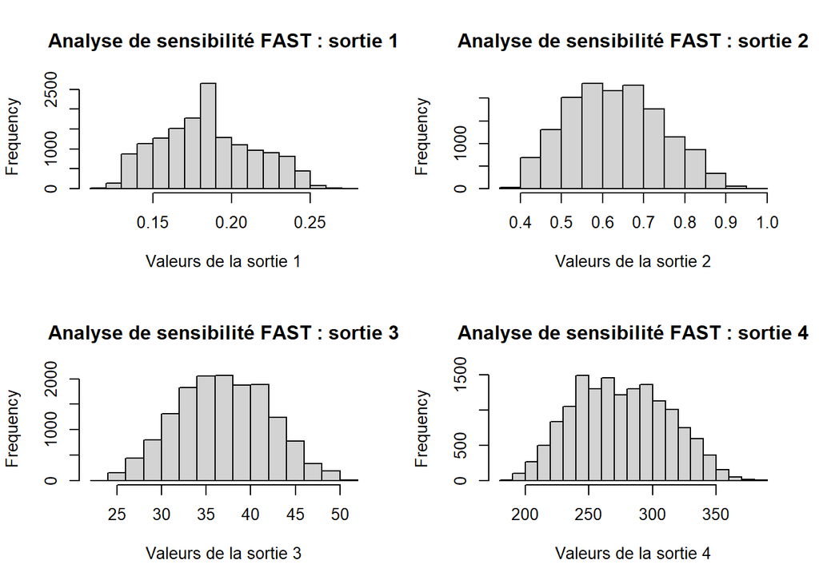

Sous la même logique, on retrouve ici des distributions de fréquence de valeurs de paramètres de sortie pour les 1000 simulations.

Dans ce cas, les comportements sont assez similaires pour les 4 sorties : on observe une plage de valeurs centrale qui sort plus fréquemment que les autres.

On peut à présent observer les résultats de l’analyse pour les 4 sorties du modèle.

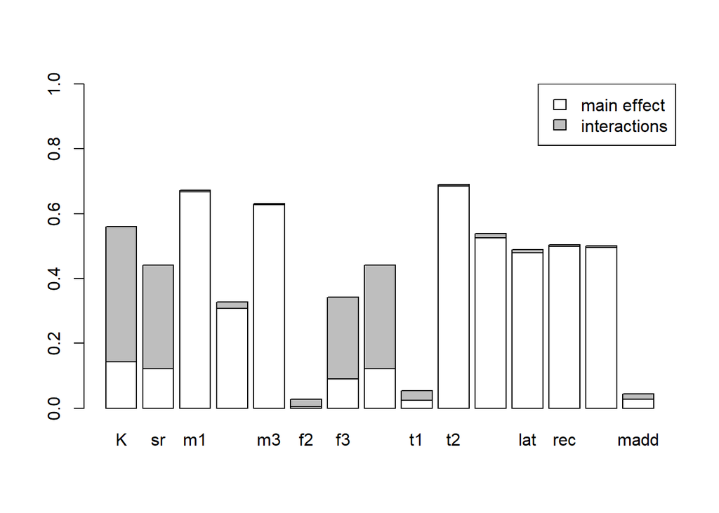

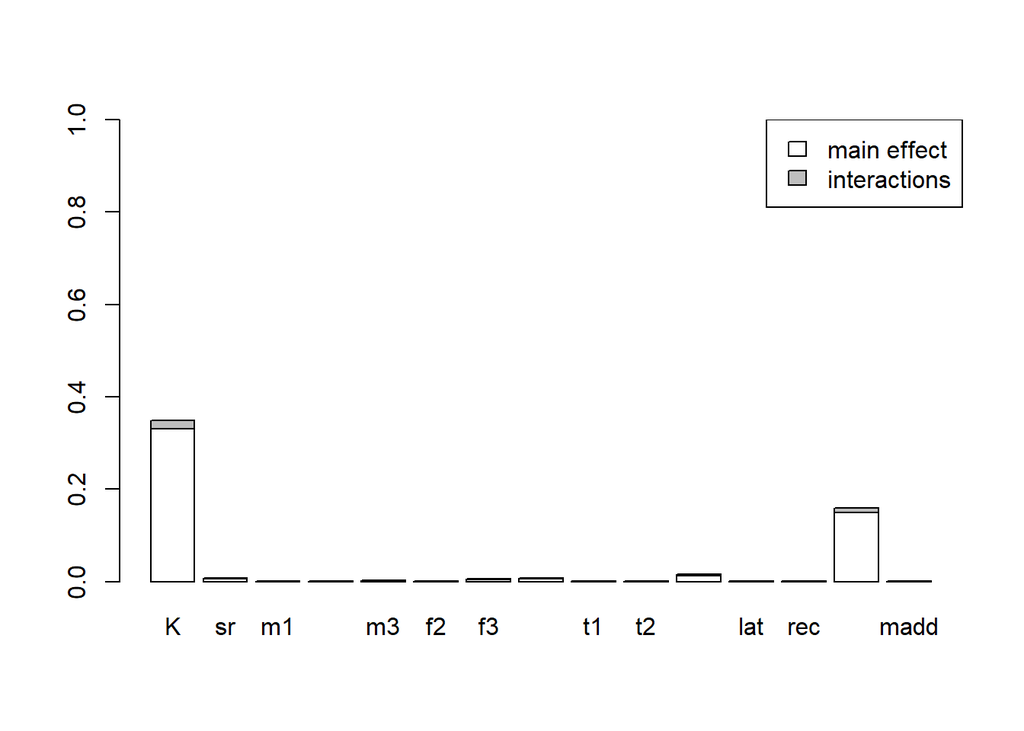

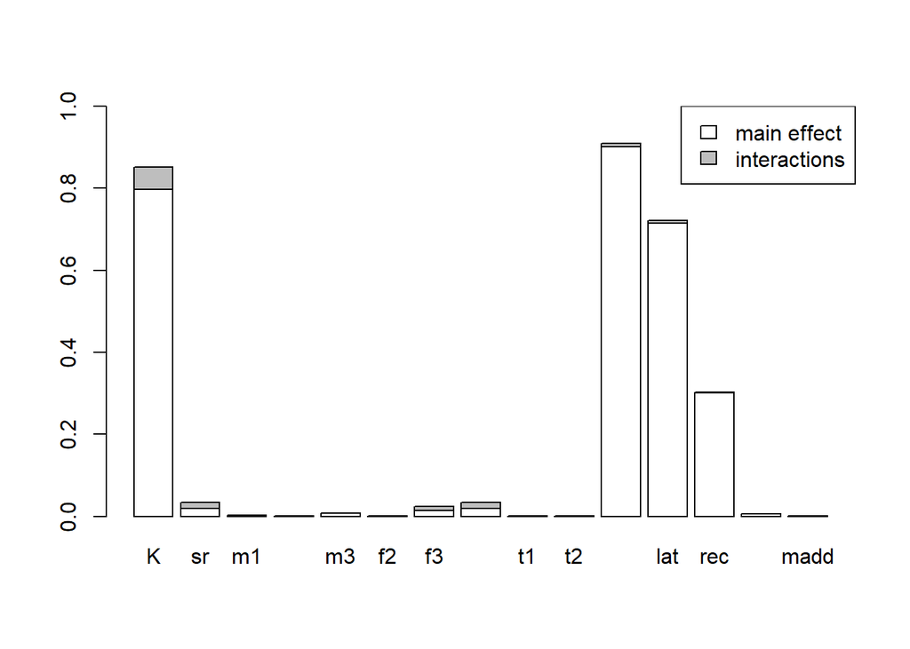

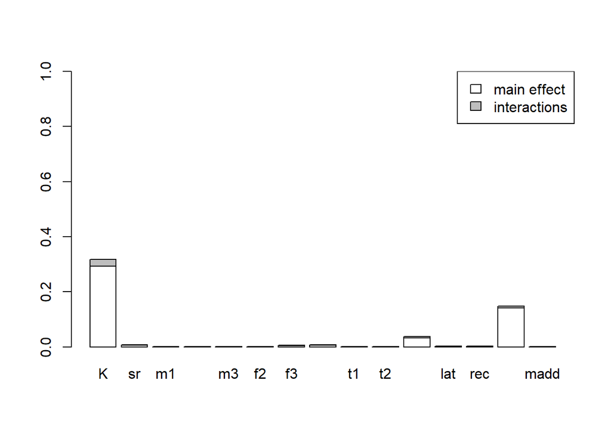

Pour chaque sortie, on obtient les indices de sensibilité pour chaque paramètre, en prenant en compte les effets principaux et les intéractions.

**Sortie 1 : Taux d’infectés (latents et infectieux) le dernier jour :**

Pour cette sortie, on observe une sensibilité particulière pour les paramètres K, sr, f3 et portee (en intéraction) et m1, m3, t2, trans, lat, rec et loss pour des effets principaux, m2 en moindre mesure.

$$\text{Taux d'infectés (latents et
infectieux) le dernier jour} = \frac{L_{N_t} +
{I_{N_t}}}{N_t}$$

D’après l’équation, nous pouvons voir que ce résultat dépend de $L_{N_t}$, $I_{N_t}$ et ${N_t}$.

Ces variables dépendent elles-même de quasiment tous les paramètres, hormis ce qui concerne les individus sains et remis, soit les paramètres f2, t1 et madd.

Les paramètres K et f3 sont en intéraction pour les naissances dans le compartiment des sains par les adultes. Nous pouvons donc imaginer qu’une population en croissance, avec un effectif grandissant, peut influencer fortement le nombre d’infectés par rapport à la population totale après un épisode d’épidémie. Ce constat peut être logique si l’on pose que plus d’individus dans une population peut induire plus de cas d’infection. Nous pouvons imaginer la même chose pour sr et portée dans le cas de la reproduction des jeunes, mais de manière légèrement moins marquée (les jeunes se reproduisant moins que les adultes).

Pour la mortalité naturelle (m1, m2 et m3), ces paramètres influent de manière importante sur la sortie, au même titre que les naissances. Nous pouvons remarquer que le taux d’infectés le dernier jour est moins sensible à m2, qui cible la classe des jeunes, qui ont une mortalité moins importante que les 2 autres classes. Le passage de la classe des jeunes à adultes constitue une sortie vers une classe qui se reproduit plus (les adultes), et donc va avoir une influence sur le résultat.

Les paramètres liés au pathogène (trans, lat, rec, loss) vont naturellement influencer le résultat car il concerne le taux d’infection final.

**Sortie 2 : Incidence de l’AP le dernier jour**

$$\text{Incidence de l'AP le dernier
jour} = \frac{transS_{N_t}I_{N_t}}{N_t}$$

Cette sortie est sensible à deux paramètres qui sont loss et K en effet principal. La présence de loss s’expliquerait par le fait que la perte d’immunité ajoute des individus dans le compartiment S (et ce de mannière plus efficace que par les naissances). Pour K, par le fait que c’est un facteur limitant des effectifs des classes d’âge, ce qui est logique car plus les effectifs dans la population d’individus sains est importante, plus d’individus peuvent être contaminés et contaminer en retour.

**Sortie 3 : Nombre maximum d’infections sur 2 ans**

$$\text{Nombre maximum d'infectieux
en 2 ans} = max(I_{N_t})$$

Le nombre maximum d’infectieux en 2 ans est surtout sensible à K, trans, lat et rec en effet principal, soit des paramètres concernant la limite des effectifs dans la population et relatifs à l’agent pathogène.

Pour rappel, l’équation permettant d’obtenir $I_{N_t}$ est :
$$I_{N_{t}}=I_{NN_{t}}+I_{J_{t}}+I_{A_{t}}$$
Avec :
$$I_{NN{t+1}} = I_{NN_t}(1 - m_{1} -
madd - t_{1} - rec) + lat . L_{NN_t}$$
$$I_{J_{t+1}} = I_{NN_t}.t_{1} + I_{J_t}(1 -
m_{2} - madd - t_{2} - rec) + lat.L_{J_t}$$
$$I_{A_{t+1}}= I_{J_t}.t_{2} + I{A_t}(1 -
m_{3} - madd - rec) + lat.L_{A_t}$$
Où l’on retrouve tous ces paramètres (K apparaît intrinsèquement du fait qu’il a une influence sur le nombre d’individus apparaissant dans la population dû aux naissances par les adultes). Les pertes, et donc la mort dûe à l’AP ne semble pas avoir d’incidence majeure sur ce résultat en revanche puisque l’on recherche une valeur maximale.

## 5. Discussion

Entre les méthodes d’analyse de sensibilité de OAT et Morris, nous ne décelons peu de différences entre les résultats pour chaque sortie. Néanmoins, la méthode OAT détécte seulement les paramètres qui ont une sensibilité monotone. Dès que le paramètre a une sensibilité en interaction avec une autre elle ne sera pas détectée. Entre ces deux méthodes, les résultats sont donc cohérants. La méthode OAT est très rapide mais ne permet pas une analyse très poussée. De plus, la méthode Morris ne prend pas beaucoup plus de temps à tourner.

Concernant FAST, comme Morris, l’espace des paramètres est plus exploré que pour OAT. En revanche, ce recouvrement des possibilités n’est pas représenté par des grilles comme Morris, ce qui le rend plus fin, car explore plus de possibilités de valeurs des paramètres (continus) et les intéractions entre paramètres. Nous pouvons le constater avec les différences marquées obtenues entre 100 et 1000 simulations. Cependant, les temps de simulation sont très coûteux en temps, et peut-être que 1000 simulations sont bien largement assez pour trouver des indices de sensibilité fiables. Il serait donc intéressant de trouver un optimum de nombre de simulations qui permettraient de trouver un compromis entre fiabilité des informations de l’analyse et temps de calcul.

Pour les résultats, FAST réussit à retrouver les paramètres de type ‘monotone’ de Morris, mais pas les autres. Cependant, il nous permet de connaître les intéractions, ce qui n’est pas possible avec Morris.

En conclusion, nous pouvons dire que Morris et FAST sont des méthodes d’analyse de sensibilité complémentaires efficaces pour connaître l’influence des paramètres d’entrée sur les sorties. OAT peut être intéressante dans le cas d’un modèle peu complexe (peu de paramètres et d’intéractions possibles) car elle est assez simple et rapide à utiliser et à interpréter. Dans le cas de la précision portée par FAST et Morris, il serait intéressant de faire des tests qui indiqueraient la significativité des résultats dans le cas du nombre de simulations et d’interprétation des résultats.

## 6. Modifications du modèle

### a. Explication des modifications

Nous faisons l’hypothèse que la transmission de l’agent pathogène est plus grande au sein d’une même classe qu’entre les classes d’âge car les individus de même classe d’âge ont plus d’intéractions.

Nous pouvons imaginer ce cas de figure pour un élevage d’individus parqués par classe d’âge, qui vont donc s’infecter plus fréquemment.

Voici les équations modifiées :

**Classe d’âge NN (Nouveaux nés)**

$$S_{NN_{t+1}} = S_{NN_t} (1 - m_{1} -
t_{1} - \frac{\color{red}{transIntra} . II_{NN_t}}{N} -
\frac{\color{red}{transInter} . (II_{J_t} + II_{A_t})}{N}) + loss .
R_{NN_t} + max( 0,\ s_{R} . portee . \sum_{J} . f_{2}) + \sum_{A} .
f_{3} (1 - \frac{N}{K})$$

$$IN_{NN_{t+1}} = IN_{NN_t}(1 - m_{1} -
t{1} - \text{lat}) + \frac{\color{red}{transIntra} . S_{NN_t} .
II_{NN_t}}{N} + \frac{\color{red}{transInter} . S_{NN_t} . (II_{J_t} +
II_{A_t})}{N}$$

$$II_{NN{t+1}} = II_{NN_t}(1 - m_{1} -
madd - t_{1} - rec) + lat . IN_{NN_t}$$

$$R_{NN{t+1}} = R_{NN_t}(1 - m_{1} - t_{1}
- loss) + rec . II_{NN_t}$$

**Classe d’âge J (Jeunes)**

$$S_{J_{t+1}} = S_{NN_t}.t_{1} + S_{J_t}(1
- m_{2} - t_{2} - \frac{\color{red}{transIntra} . II_{J_t}}{N} -
\frac{\color{red}{transInter} . (II_{NN_t} + II_{A_t})}{N}) +
loss.R_{J_t}$$

$$IN_{J_{t+1}} = IN_{NN_t}.t_{1} +
IN_{J_t}(1 - m_{2} - t_{2} - lat) + \frac{\color{red}{transIntra} .
S_{J_t} . II_{J_t}}{N} + \frac{\color{red}{transInter} . S_{J_t} .
(II_{NN_t} + II_{A_t})}{N}$$

$$II_{J_{t+1}} = II_{NN_t}.t_{1} +
II_{J_t}(1 - m_{2} - madd - t_{2} - rec) + lat.IN_{J_t}$$

$$R_{J_{t+1}} = R_{NN_t}.t_{1} + R{J_t}(1
- m_{2} - t_{2} - loss) + rec.II_{J_t}$$

**Classe d’âge A (Adultes)**

$$S_{A_{t+1}} = S_{J_t}.t_{2} + S_{A_t}(1
- m_{3} - \frac{\color{red}{transIntra} . II_{A_t}}{N} -
\frac{\color{red}{transInter} . (II_{NN_t} + II_{J_t})}{N}) +
loss.R_{A_t}$$

$$IN_{A_{t+1}} = IN_{J_t}.t_{2} +
IN_{A_t}(1 - m_{3} - lat) + \frac{\color{red}{transIntra} . S_{A_t} .
II_{A_t}}{N} + \frac{\color{red}{trandInter} . S_{A_t} . (II_{NN_t} +
II_{J_t})}{N}$$

$$II_{A_{t+1}}= II_{J_t}.t_{2} + II{A_t}(1
- m_{3} - madd - rec) + lat.IN_{A_t}$$

$$R_{A_{t+1}}=R_{J_t}.t_{2}+R_{A_t}(1-m_{3}-loss)+rec.II_{A_t}$$

**Total**
$$S_{N_{t+1}}=S_{NN_{t+1}}+S_{J_{t+1}}+S_{A_{t+1}}$$

$$IN_{N_{t+1}}=IN_{NN_{t+1}}+IN_{J_{t+1}}+IN_{A_{t+1}}$$

$$II_{N_{t+1}}=II_{NN_{t+1}}+II_{J_{t+1}}+II_{A_{t+1}}$$

$$R_{N_{t+1}}=R_{NN_{t+1}}+R_{J_{t+1}}+R_{A_{t+1}}$$

**Niveau d’infectiosité de l’agent pathogène par jour**

$$Nv_{inf_{t+1}}=\color{red}{transIntra}.S_{N_t}(\frac{II_{N_t}}{N})
+ \color{red}{transInter}.S_{N_t}(\frac{II_{N_t}}{N})$$

### b. Réaliser les mêmes analyses de sensibilité (OAT, Morris, FAST)

Modélisation du nouveau modèle

```r
modApplimodif <- function(parametre){

  # CONDITIONS DE SIMULATION
  temps = 2*365; # nb de pas de temps (en jours)
  # initialisation pour la sauvegarde de 4 sorties ponctuelles pour chaque jeu de parametres
  sorties <- matrix(0, nrow=nrow(parametre), ncol=4)

  # boucle des scenarios de l'?chantillonnage de l'AS
  for (i in 1:nrow(parametre)) {

    # STRUCTURE & PARAMETRES DU MODELE

    # Parametres demographiques
    K = parametre[i,1];         # Nombre maximal d'individus que le milieu peut supporter
    sr = parametre[i,2];        # Sex-ratio
    m1 = parametre[i,3];        # Mortalité naturelle des nouveaux-nés
    m2 = parametre[i,4];        # Mortalité naturelle des jeunes
    m3 = parametre[i,5];        # Mortalité naturelle des adultes
    f2 = parametre[i,6];        # Taux de fécondité des jeunes
    f3 = parametre[i,7];        # Taux de fécondité des adultes
    portee = parametre[i,8];    # Effectif maximal d'une portée
    t1 = parametre[i,9];        # Probabilité de passage de la classe d'âge "nouveau-né" à "jeune"
    t2 = parametre[i,10];       # Probabilité de passage de la classe d'âge "jeune" à "adulte"

    # Parametres lies a l'agent pathogène
    trans_inter = parametre[i,11]; # force d'infection inter-classe
    trans_intra = parametre[i,12]; # force d'infection intra-classe
    lat = parametre[i,13];    # Taux de la latence
    rec = parametre[i,14];    # Taux de passage à un état d'immmunité
    loss = parametre[i,15];   # Taux de passage d'un état d'immunité à un état sensible (sain)
    madd = parametre[i,16];   # Mortalité lié à l'infection par l'AP

    # INITIALISATION
    MAT <- array(0, dim=c(4,4,temps)); # nb indiv par classe d'age en ligne (derniere ligne = pop tot), etat de sante en colonne, pas de temps (dimension 3)
    nvinf <- array(0, dim=c(temps));
    # conditions initiales (la population est a sa structure d'equilibre, calculee par ailleurs)
    MAT[1,1,1] <- 27; # Effectif des individus nouveaux-nes sains le premier jour
    MAT[2,1,1] <- 23; # Effectif des individus jeunes sains le premier jour
    MAT[3,1,1] <- 36; # Effectif des individus adultes sains le premier jour
    MAT[3,3,1] <- 1;  # Effectif des individus adultes infectes infectieux le premier jour

    # Effectifs par etat de sante
    MAT[4,1,1] <- sum(MAT[1:3,1,1]); MAT[4,2,1] <- sum(MAT[1:3,2,1]); MAT[4,3,1] <- sum(MAT[1:3,3,1]); MAT[4,4,1] <- sum(MAT[1:3,4,1]);

    # SIMULATIONS
    # Boucle du temps
    for (t in 1:(temps-1)) {
      # Classe d'age Nouveau-né
      # RQ : les naissances sont XX, les nouveaux nes etant dans l'etat NN
      N <- sum(MAT[4,,t]);  # taille de la pop en t
      MAT[1,1,t+1] <- MAT[1,1,t]*(1-m1-t1-trans_inter*MAT[2,3,t]*MAT[3,3,t]- trans_intra*MAT[1,3,t]/N )+ loss*MAT[1,4,t]
      + max(0, sr*portee*(sum(MAT[2,,t])*f2 + sum(MAT[3,,t])*f3) * (1 - N/K));
      MAT[1,2,t+1] <- MAT[1,2,t]*(1-m1-t1-lat) + MAT[1,1,t]*(trans_inter*MAT[2,3,t]*MAT[3,3,t]+trans_intra*MAT[1,3,t])/N;
      MAT[1,3,t+1] <- MAT[1,3,t]*(1-m1-madd-t1-rec) + lat*MAT[1,2,t];
      MAT[1,4,t+1] <- MAT[1,4,t]*(1-m1-t1-loss) + rec*MAT[1,3,t];
      # Les jeunes
      MAT[2,1,t+1] <- MAT[1,1,t]*t1 + MAT[2,1,t]*(1-m2-t2-trans_inter*MAT[1,3,t]*MAT[3,3,t]- trans_intra*MAT[2,3,t]/N) + loss*MAT[2,4,t];
      MAT[2,2,t+1] <- MAT[1,2,t]*t1 + MAT[2,2,t]*(1-m2-t2-lat) + MAT[2,1,t]*(trans_inter*MAT[1,3,t]*MAT[3,3,t] + trans_intra*MAT[2,3,t])/N;
      MAT[2,3,t+1] <- MAT[1,3,t]*t1 + MAT[2,3,t]*(1-m2-madd-t2-rec) + lat*MAT[2,2,t];
      MAT[2,4,t+1] <- MAT[1,4,t]*t1 + MAT[2,4,t]*(1-m2-t2-loss) + rec*MAT[2,3,t];
      # Les adultes
      MAT[3,1,t+1] <- MAT[2,1,t]*t2 + MAT[3,1,t]*(1-m3-trans_inter*MAT[1,3,t]*MAT[2,3,t]- trans_intra*MAT[3,3,t]/N) + loss*MAT[3,4,t];
      MAT[3,2,t+1] <- MAT[2,2,t]*t2 + MAT[3,2,t]*(1-m3-lat) + MAT[3,1,t]*(trans_inter*MAT[1,3,t]*MAT[2,3,t] + trans_intra*MAT[3,3,t])/N;
      MAT[3,3,t+1] <- MAT[2,3,t]*t2 + MAT[3,3,t]*(1-m3-madd-rec) + lat*MAT[3,2,t];
      MAT[3,4,t+1] <- MAT[2,4,t]*t2 + MAT[3,4,t]*(1-m3-loss) + rec*MAT[3,3,t];
      # calcul des effectifs  N par etat de sante
      MAT[4,1,t+1] <- sum(MAT[1:3,1,t+1]);
      MAT[4,2,t+1] <- sum(MAT[1:3,2,t+1]);
      MAT[4,3,t+1] <- sum(MAT[1:3,3,t+1]);
      MAT[4,4,t+1] <- sum(MAT[1:3,4,t+1]);
      nvinf[t+1]   <- trans_intra*MAT[4,1,t]*MAT[4,3,t]/N + trans_inter*MAT[4,1,t]*MAT[4,3,t]/N

    }# fin boucle temps

    # Sorties ponctuelles a analyser

    # Taux des infectes au dernier jours
    sortie1 <- (MAT[4,2,temps] + MAT[4,3,temps]) / sum(MAT[4,,temps])
    # Incidence du dernier jour
    sortie2 <- nvinf[temps]
    # Nombre maximum d'infectes infectieux sur les 2 ans
    sortie3 <- max(MAT[4,3,1:temps])
    # Incidence sur l'année
    sortie4 <- sum(nvinf[1:365])

    sorties[i,1] <- sortie1;
    sorties[i,2] <- sortie2;
    sorties[i,3] <- sortie3;
    sorties[i,4] <- sortie4;

  }# fin boucle scenarios AS
  return(sorties)
} # fin fonction du modele
```

```
##       Taux_inf Last_incidence Nbr_infectes Year_incidence
## [1,] 0.1206719       1.002249     8.223539       875.6076
```

#### Méthode OAT

Stocker les variations des paramètres

Réaliser l’analyse de sensibilité OAT pour chaque paramètre

```r
for (i in 1:length(ValNominale)) {
  for (j in 1:10) {
    #Matrice avec 1 parametre qui vari
    param_matrix <- param_matrix_first
    param_matrix[1,i] <- param_matrix_var[j,i]

    # Exécuter le modèle pour chaque combinaison de paramètres
    output <- modApplimodif(param_matrix)

    # Créez un data.frame temporaire pour stocker les résultats de cette itération
    temp_df <- data.frame(Parameter = ParamNames[i],
                          Val = param_matrix[, i],
                          Sensitivity1 = output[,1],
                          Sensitivity2 = output[,2],
                          Sensitivity3 = output[,3],
                          Sensitivity4 = output[,4])

    # Ajoutez les résultats à SensitivityResults1
    SensitivityResults_2 <- rbind(SensitivityResults_2, temp_df)
  }
}
```

Réaliser un graphique par sortie : Taux d’infecté dernier jour, Incidence dernier jour, Nombre d’infecté infectieux, Somme de l’incidence à l’année

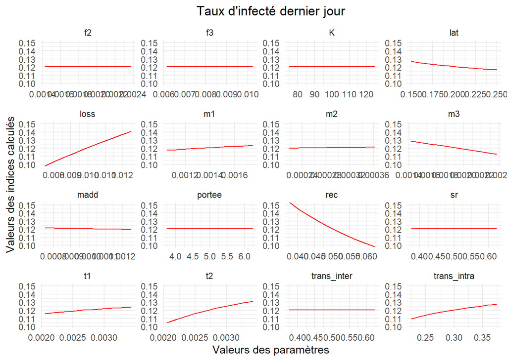

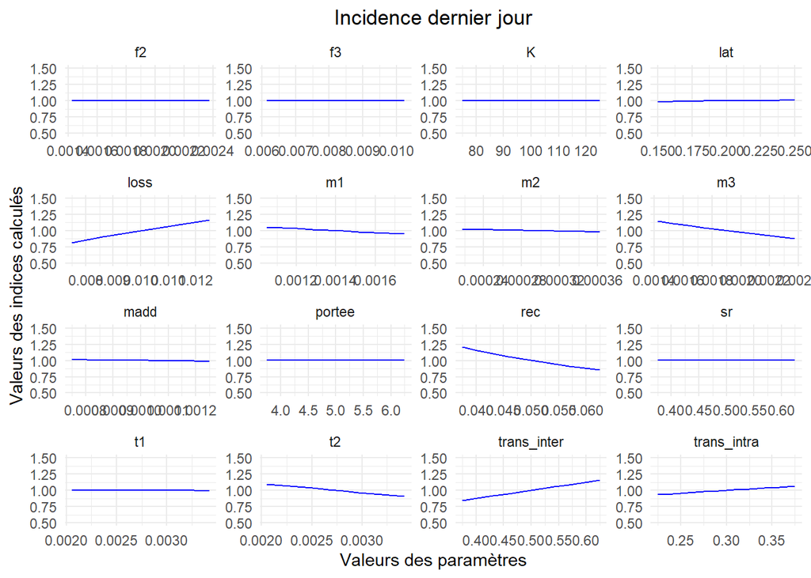

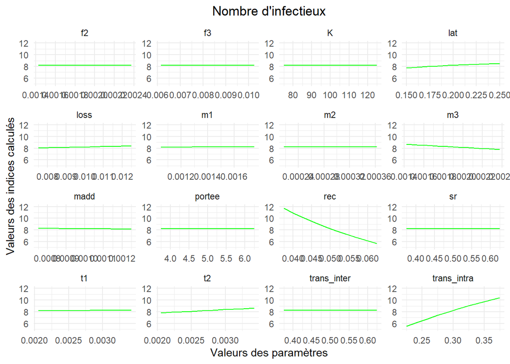

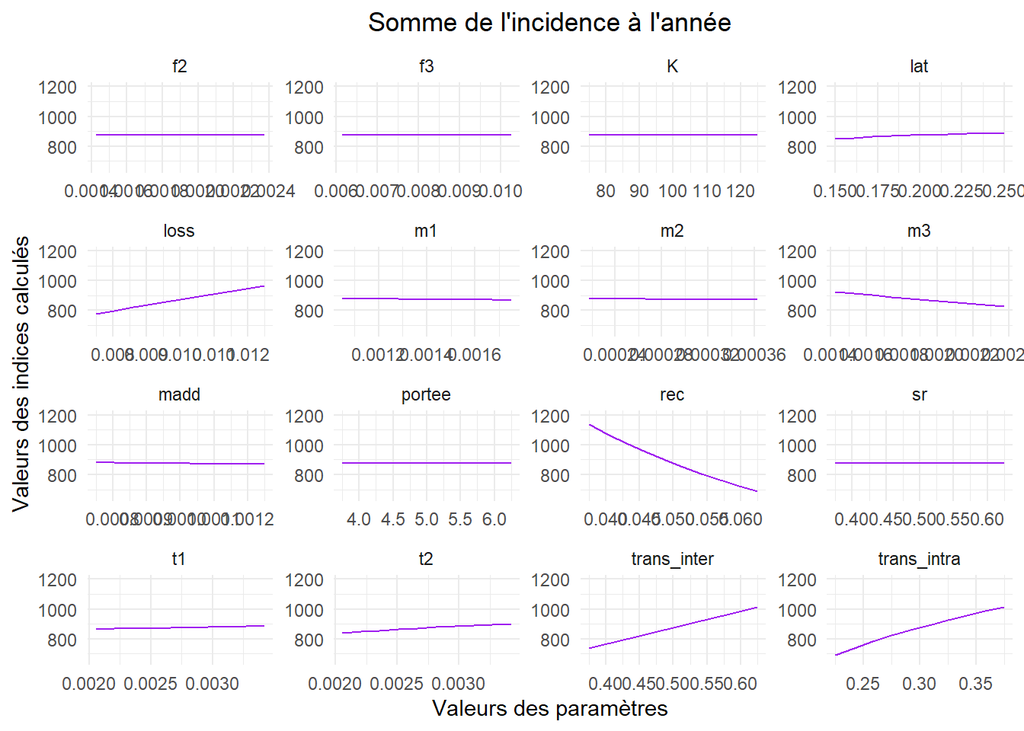

#### Méthode Morris

Définir les paramètres de l’analyse Morris

```r
n <- 100  # Nombre de trajectoires
p <- length(ValNominale)  # Nombre de paramètres
lower <- ValNominale*0.75
upper <- ValNominale*1.25
```

Réaliser l’analyse de sensibilité Morris

```r
morris_results <- morris(model = modApplimodif,
                         factors = p,
                         r = n,
                         design = list(type = "oat", levels = 6, grid.jump = 3),
                         binf = lower,
                         bsup = upper,
                         scale=T)
```

Afficher les graphiques

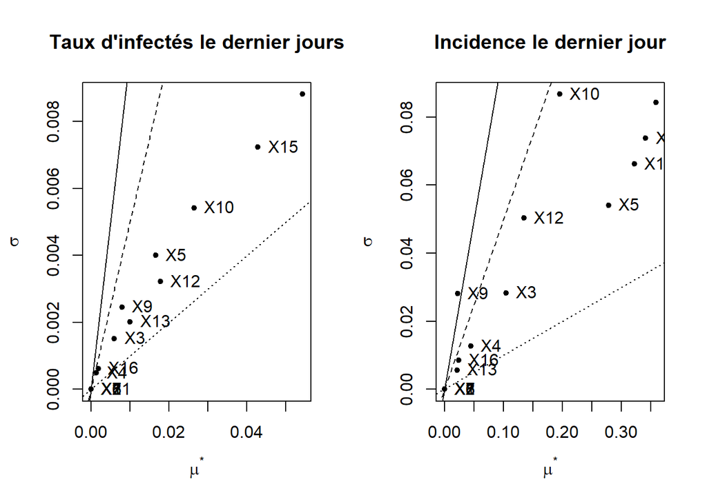

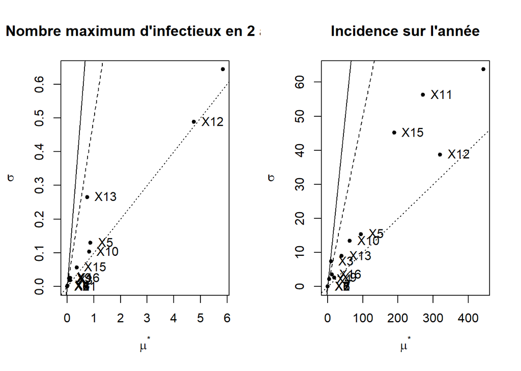

$\sigma$ mesure les interactions et les relations non linéaires entre les paramètres.  
$\mu$* mesure la sensibilité du paramètre.  
Les mêmes bornes que pour l’analyse du modèle de base sont ajoutées.  
L’espace le plus à gauche signifie que le paramètre est non linéaire et/ou non monotone.  
Ensuite, la zone détermine les paramètres toujours monotone.  
Ensuite, les paramètres sont monotones.  
Enfin, les paramètres sont linéaires.

- Le taux d’infectés le dernier jours est influencé de manière monotone par les paramètres **m1**, **m3**, **t1**, **t2**, **trans_intra**, **lat**, **rec** et **loss**. Ces paramètres sont sensibles de manières monotones, ils ont donc été également identifiés par la méthode OAT.
- L’incidence le dernier jour est influencée de manière non linéaire et/ou non monotone par le paramètre **t1**. Les paramètres **m1**, **m3**, **t2**, **trans_inter**, **trans_intra**, **rec**, **loss** influence cette sortie de manière monotone. Les paramètres monotones ont tous été identifiés par la méthode OAT.
- Le nombre maximum d’infectieux en une journée est influencé par les paramètres **m3**, **t2**, **trans_intra**, **lat**, **rec**, ils ont une sensibilité monotone.
- L’incidence à l’année est influencée par les paramètres **m3**, **t2**, **trans_inter**, **trans_intra**, **lat**, **rec**, **loss** qui ont une sensibilité monotones.

#### Méthode FAST

**Design expérimental** On fait donc l’analyse de sensibilité FAST pour 1000 simulations.

```r
ParamRanges<-apply( X = cbind(inf = ValNominale*0.75, sup = ValNominale*1.25), 1, function(x){list(min=x[1], max = x[2])}) # plage de variation des paramètres en tant que liste de listes
des_xp1000<-fast99(model = NULL,
                   factors = ParamNames,
                   n = 1000,
                   q = rep("qunif",16),
                   q.arg = ParamRanges) # Pour creer le design expérimental
des_xp2<-des_xp1000$X # On conserve le tableau avec les variations par paramètres
length(des_xp2[,1]) # Longueur du tableau
```

```
## [1] 16000
```

On a donc un tableau avec 16000 paramètres puisqu’on en a ajouté un.

**Application au modèle modifié**

```r
FASTmod<-fast99(model = modApplimodif, factors = ParamNames, n = 1000, q = rep("qunif",16), q.arg = ParamRanges)
```

On peut à présent observer les résultats de l’analyse pour les 4 sorties du modèle.

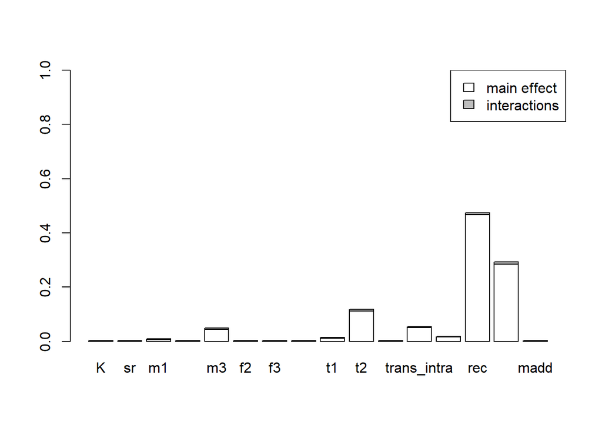

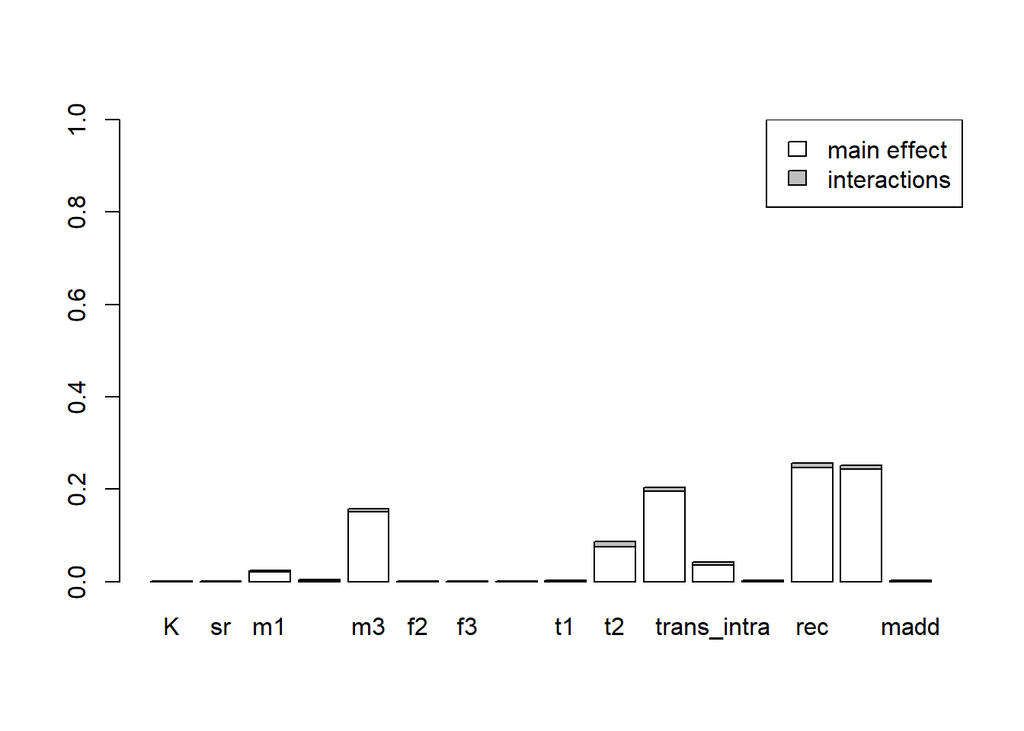

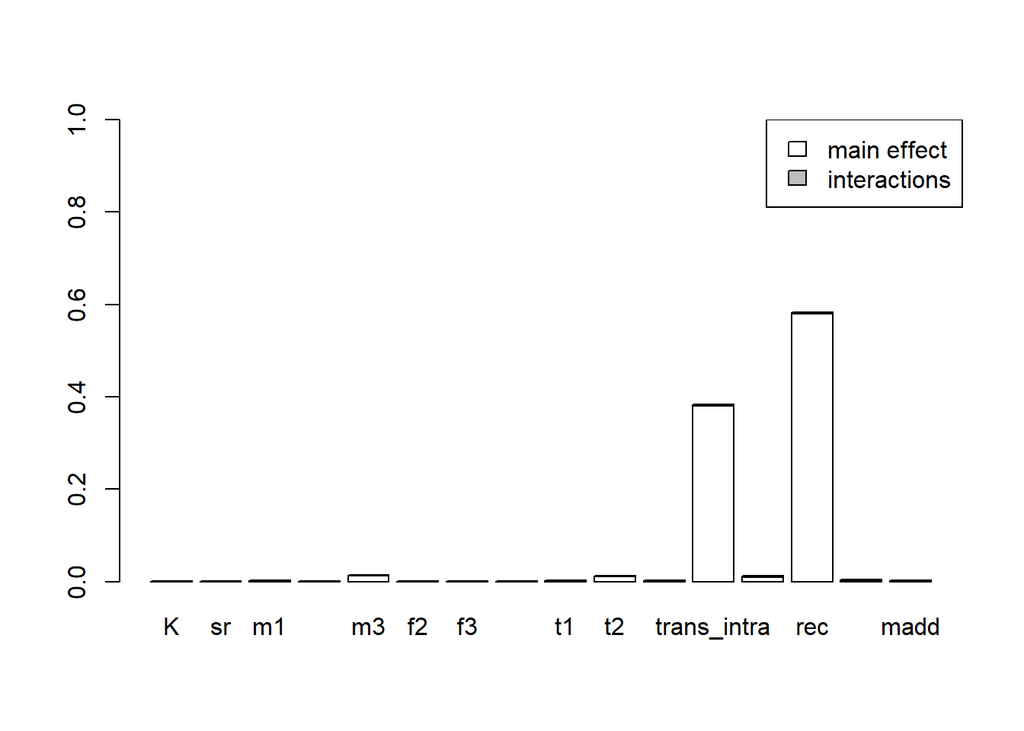

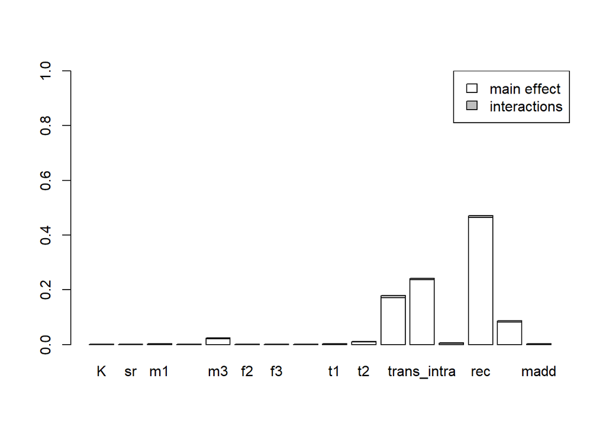

Pour chaque sortie, on obtient les indices de sensibilité pour chaque paramètre, en prenant en compte les effets principaux et les intéractions.

**Sortie 1 : Taux d’infectés (latents et infectieux) le dernier jour :**

Cette fois, on observe une sensibilité à rec, loss et t2, m3 et trans_intra en moindre mesure pour les effets principaux.

Dans ce cas, moins de paramètres influent ce résultat et ne sont pas en intéraction. C’est le cas des naissances dans le compartiment des sains par exemple. Ici, le taux d’infectés est influencé par les paramètres concernant le pathogène principalement, ce qui est logique car on s’intéresse au taux d’infectés final.

$$\text{Taux d'infectés (latents et
infectieux) le dernier jour} = \frac{L_{N_t} +
{I_{N_t}}}{N_t}$$

**Sortie 2 : Incidence de l’AP le dernier jour**

$$\text{Incidence de l'AP le dernier
jour} = \frac{transS_{N_t}I_{N_t}}{N_t}$$

L’incidence de l’AP le dernier jour est influencée par m3, trans_inter, rec et loss, et t2 et trans_intra en moindre mesure, uniquement en effets principaux. Dans le premier modèle, cette valeur était sensible à loss et K uniquement.

Il est possible que trans_inter soit influent car il impacte directement toutes les classes d’âge, tandis que trans_intra est moins influent, car le passage à la classe d’âge supérieur est plus lent. Rec et loss concernent les individus qui entrent et qui sortent d’un état d’immunité, ce qui est important car on souhaite connaître l’effet de l’agent pathogène sur la population, et donc les individus sains.

**Sortie 3 : Nombre maximum d’infections sur 2 ans**

$$\text{Nombre maximum d'infectieux
en 2 ans} = max(I_{N_t})$$

Trans_intra et rec en effets principaux sont les paramètres qui vont avoir un effet important sur le nombre maximal d’infectieux sur 2 ans. Nous retrouvons de nouveau rec, qui vient influencer le résultat par la perte de l’état infectieux. En revanche, trans_intra a une inlfuence possiblement positive, car il s’agit d’une valeur élevée de transmission de l’agent pathogène, ce qui va donc avoir plus d’effet que trans_intra par exemple.

**Sortie 4 : Incidence de l’AP sur 1 an**

$$\text{Incidence de l'AP sur 1 an} =
\sum_{t=1}^{365}\frac{transS_{N_t}I_{N_t}}{N_t}$$

Pour ce résultat, ce sont trans_intra, trans_inter, rec et loss en effets principaux pour lesquels il est le plus sensible. On retrouve bien ici trans et loss. Le fait de perdre l’immunité vient contrebalancer les forts taux de transmission.

**Globalement, l’effet limitant de K n’est plus une composante du modèle qui va avoir une influence importante, contrairement aux deuc facteurs de transmission.**

### c. Discussion et comparaison entre les modèles

Globalement, les paramètres trans_intra et trans_inter ont une influence plus importante sur le modèle modifié que trans dans le premier modèle. Nous pouvons le constater car les résultats des analyses sont assez différents entre les 2 modèles, en particulier moins d’intéractions sont présentes.

Les sorties sont devenues plus sensibles aux paramètres liés à l’agent pathogène (en particulier de transmission) que les paramètres démographiques, qui avaient tout de même une certaine influence dans le premier modèle (en particulier K).

Préciser les transmissions en intra-classe et inter-classe ont donc permis de rendre compte de paramètres influents bien différents dans le cadre de notre exemple, à savoir un élevage avec des classes d’âge parquées ensemble, ce qui prouve que l’environnement des individus peut avoir un effet important sur la dynamique d’un modèle et ses résultats.